# Investigate_a_Dataset

### Data Cleaning

In this part of the investigation I will have a closer look the dataset in terms of duplicates, null values and datatypes

1. Check for duplicates and drop duplicates in the dataset

```python
# identify number of duplicates in the data set
df.duplicated().sum()
```

```
1
```

```python
# the dataset has 1 duplicate which I will drop from the dataset
df.drop_duplicates(inplace=True)
```

```python
# identify number of duplicates in the data set after dropping null values in order to doublecheck my operation
df.duplicated().sum()
```

```
0
```

1. Check the dataset for Null values and drop them from the data

```python
# identify number of null values in the data set
df.isnull().sum()
```

```
id                         0
imdb_id                   10
popularity                 0
original_title             0
runtime                    0
genres                    23
production_companies    1030
release_date               0
vote_average               0
release_year               0
budget_adj                 0
revenue_adj                0
dtype: int64
```

```python
# dropping the null values from the data set
df.dropna(inplace=True)
```

Now I will have a quick look at the data to see how many data I have left after this operation

```python
df.shape
```

```
(9822, 12)
```

1. Now I will discuss the datatypes and adress any problems that need to be fixed and then perform those cleaning steps

```python
df.dtypes
```

```
id                        int64
imdb_id                  object
popularity              float64
original_title           object
runtime                   int64
genres                   object
production_companies     object
release_date             object
vote_average            float64
release_year              int64
budget_adj              float64
revenue_adj             float64
dtype: object
```

```python
# closer inspection of the object imdb_id
type(df['imdb_id'][0])
```

```
str
```

```python
# closer inspection of the object genres
type(df['genres'][0])
```

```
str
```

```python
# closer inspection of the object original title
type(df['original_title'][0])
```

```
str
```

```python
# closer inspection of the object production_companies
type(df['production_companies'][0])
```

```
str
```

```python
# closer inspection of the object release_date
type(df['release_date'][0])
```

```
str
```

All inspected objects are strings

Since I just need the month and year for my investigation, I will extrect the month from the column and save it as integer

```python
# creating a new variable called release_month, in which I split the release date between the "/" and just return the
# the first "letter" of the string (which is the month) and save it as a integer
release_month = df.release_date.str.split('/').str.get(0).astype(int)
```

```python
# Now I add release_month as a new column to the dataframe and drop the column release_date from the dataframe
df['release_month'] = release_month
df.drop('release_date', axis= 1, inplace=True)
```

Then I will double check my operations

```python
# Then I will double check my operations by displaying the first row of the dataframe and have a look at the datatypes
df.head(1)
```

|  | id | imdb_id | popularity | original_title | runtime | genres | production_companies | vote_average | release_year | budget_adj | revenue_adj | release_month |
| --- | --- | --- | --- | --- | --- | --- | --- | --- | --- | --- | --- | --- |
| 0 | 135397 | tt0369610 | 32.985763 | Jurassic World | 124 | Action\|Adventure\|Science Fiction\|Thriller | Universal Studios\|Amblin Entertainment\|Legenda... | 6.5 | 2015 | 1.379999e+08 | 1.392446e+09 | 6 |

```python
df.dtypes
```

```
id                        int64
imdb_id                  object
popularity              float64
original_title           object
runtime                   int64
genres                   object
production_companies     object
vote_average            float64
release_year              int64
budget_adj              float64
revenue_adj             float64
release_month             int64
dtype: object
```

In the next steps I will performe the follwoing operations

1. convert budget and revenue to integer to make it more easier to plot them later & rename them (I would like to have them without the "_" -suffix)
2. split genres and production_companies in order to access all information in the column
1. converting & renaming budget, revenue

```python
# converting budget_adj & revenue_adj into integer
df.budget_adj = df.budget_adj.astype(int)
df.revenue_adj = df.revenue_adj.astype(int)
```

```python
# renaming the variables budget_adj & revenue_adj to budget and revenue
df.rename(columns={'budget_adj' : 'budget', 'revenue_adj' : 'revenue'}, inplace=True)
```

Double check the operation

```python
df.info()
```

```
<class 'pandas.core.frame.DataFrame'>
Int64Index: 9822 entries, 0 to 10865
Data columns (total 12 columns):
id                      9822 non-null int64
imdb_id                 9822 non-null object
popularity              9822 non-null float64
original_title          9822 non-null object
runtime                 9822 non-null int64
genres                  9822 non-null object
production_companies    9822 non-null object
vote_average            9822 non-null float64
release_year            9822 non-null int64
budget                  9822 non-null int64
revenue                 9822 non-null int64
release_month           9822 non-null int64
dtypes: float64(2), int64(6), object(4)
memory usage: 997.5+ KB
```

```python
df.head(1)
```

|  | id | imdb_id | popularity | original_title | runtime | genres | production_companies | vote_average | release_year | budget | revenue | release_month |
| --- | --- | --- | --- | --- | --- | --- | --- | --- | --- | --- | --- | --- |
| 0 | 135397 | tt0369610 | 32.985763 | Jurassic World | 124 | Action\|Adventure\|Science Fiction\|Thriller | Universal Studios\|Amblin Entertainment\|Legenda... | 6.5 | 2015 | 137999939 | 1392445892 | 6 |

```python
# now I will have a closer look the columns budget and revenue
df.budget.describe()
```

```
count    9.822000e+03
mean     1.931995e+07
std      3.560094e+07
min      0.000000e+00
25%      0.000000e+00
50%      2.167060e+05
75%      2.432644e+07
max      4.250000e+08
Name: budget, dtype: float64
```

```python
df.revenue.describe()
```

```
count    9.822000e+03
mean     5.676379e+07
std      1.511181e+08
min      0.000000e+00
25%      0.000000e+00
50%      0.000000e+00
75%      4.249280e+07
max      2.827124e+09
Name: revenue, dtype: float64
```

One can see that there are movies that have a budget or revenue 0$ which sounds not really logical. These rows needs to be dropped from the data set. So I decided to drop values = 0.0 from the dataframe (not just from revenue and budget, but also from runtime)

```python
# in the first step I will replace all 0 values with NaN
df.replace(0, np.nan, inplace=True)
```

```python
# checking for new null values that the above operations has created
df.isnull().sum()
```

```
id                         0
imdb_id                    0
popularity                 0
original_title             0
runtime                   13
genres                     0
production_companies       0
vote_average               0
release_year               0
budget                  4792
revenue                 5069
release_month              0
dtype: int64
```

```python
# dropping the null values from the data set which I created by just including values >0
df.dropna(axis=0, inplace=True)
```

```python
df.info()
```

```
<class 'pandas.core.frame.DataFrame'>
Int64Index: 3807 entries, 0 to 10848
Data columns (total 12 columns):
id                      3807 non-null int64
imdb_id                 3807 non-null object
popularity              3807 non-null float64
original_title          3807 non-null object
runtime                 3807 non-null float64
genres                  3807 non-null object
production_companies    3807 non-null object
vote_average            3807 non-null float64
release_year            3807 non-null int64
budget                  3807 non-null float64
revenue                 3807 non-null float64
release_month           3807 non-null int64
dtypes: float64(5), int64(3), object(4)
memory usage: 386.6+ KB
```

The dataframe contains now 3807 rows with non-null values

1. split genres & production_companies

```python
# creating new datafram by splitting the variable genre by '|' and saving every value of each split in a own column
df_genres_split = df.genres.str.split('|', expand=True)
df_genres_split.head()
```

|  | 0 | 1 | 2 | 3 | 4 |
| --- | --- | --- | --- | --- | --- |
| 0 | Action | Adventure | Science Fiction | Thriller | None |
| 1 | Action | Adventure | Science Fiction | Thriller | None |
| 2 | Adventure | Science Fiction | Thriller | None | None |
| 3 | Action | Adventure | Science Fiction | Fantasy | None |
| 4 | Action | Crime | Thriller | None | None |

```python
# creating new dataframe by splitting the variable production_companies by '|' and saving every value of each split
# in a own column.
df_production_companies_split = df.production_companies.str.split('|', expand=True)
df_production_companies_split.head()
```

|  | 0 | 1 | 2 | 3 | 4 |
| --- | --- | --- | --- | --- | --- |
| 0 | Universal Studios | Amblin Entertainment | Legendary Pictures | Fuji Television Network | Dentsu |
| 1 | Village Roadshow Pictures | Kennedy Miller Productions | None | None | None |
| 2 | Summit Entertainment | Mandeville Films | Red Wagon Entertainment | NeoReel | None |
| 3 | Lucasfilm | Truenorth Productions | Bad Robot | None | None |
| 4 | Universal Pictures | Original Film | Media Rights Capital | Dentsu | One Race Films |

By looking at the first 5 coloumns, I can see that the split columns have null values. I need to know how many null values they have exactly in order to determine if how to use the data

```python
#identify number of null values in the data set df_production_companies_split
df_production_companies_split.isnull().sum()
```

```
0       0
1     884
2    1836
3    2620
4    3116
dtype: int64
```

```python
#identify number of null values in the data set df_genres_split
df_genres_split.isnull().sum()
```

```
0       0
1     637
2    1716
3    2943
4    3552
dtype: int64
```

After spliting the genres and the production_companies columns, one can see that both columns have a lot of null values which would make my dataset really small if I would delete all null values. Furthtermore, one can assume that the head genre and the head production company of every movie, will be named first in each list. Therefore, I decided to just include the first value of each list in the dataframe

Including the first column of df_genres_split & df_production_companies_split in the datafram df

```python
# adding the first column of df_genres_split & df_production_companies_split in the datafram df
df['new_genre']= df_genres_split[0]
df['new_production_companies']= df_production_companies_split[0]
```

double check if the operation was succesfull

```python
df.head(1)
```

|  | id | imdb_id | popularity | original_title | runtime | genres | production_companies | vote_average | release_year | budget | revenue | release_month | new_genre | new_production_companies |
| --- | --- | --- | --- | --- | --- | --- | --- | --- | --- | --- | --- | --- | --- | --- |
| 0 | 135397 | tt0369610 | 32.985763 | Jurassic World | 124.0 | Action\|Adventure\|Science Fiction\|Thriller | Universal Studios\|Amblin Entertainment\|Legenda... | 6.5 | 2015 | 137999939.0 | 1.392446e+09 | 6 | Action | Universal Studios |

```python
# checking for null values in the dataframe
df.isnull().sum()
```

```
id                          0
imdb_id                     0
popularity                  0
original_title              0
runtime                     0
genres                      0
production_companies        0
vote_average                0
release_year                0
budget                      0
revenue                     0
release_month               0
new_genre                   0
new_production_companies    0
dtype: int64
```

now I'm droppin the original columns & # double check if the operation was succesfull

```python
# dropping the columns 'genres', 'production_companies' from the dataframe
df.drop(['genres', 'production_companies'], axis=1, inplace=True)
```

```python
df.head(1)
```

|  | id | imdb_id | popularity | original_title | runtime | vote_average | release_year | budget | revenue | release_month | new_genre | new_production_companies |
| --- | --- | --- | --- | --- | --- | --- | --- | --- | --- | --- | --- | --- |
| 0 | 135397 | tt0369610 | 32.985763 | Jurassic World | 124.0 | 6.5 | 2015 | 137999939.0 | 1.392446e+09 | 6 | Action | Universal Studios |

```python
df.dtypes
```

```
id                            int64
imdb_id                      object
popularity                  float64
original_title               object
runtime                     float64
vote_average                float64
release_year                  int64
budget                      float64
revenue                     float64
release_month                 int64
new_genre                    object
new_production_companies     object
dtype: object
```

```python
# closer inspection of the object new_genre
type(df['new_genre'][0])
```

```
str
```

```python
# closer inspection of the object new_production_companies
type(df['new_production_companies'][0])
```

```
str
```

This was the last in the data wrangling process. Now the dataset is ready for the investigation

## Exploratory Data Analysis

### Are there factors that could predict the success of a movie?

#### 1.What kinds of properties are associated with movies that have high revenues: Does the budget, the release month, the runtime, the production company of the rating, (does high rated movies generate more income?) have a postive effect on the revenue?

### Histogramm for various features- for an first overview of the factors

Source for interpretation: https://www.dummies.com/education/math/statistics/how-to-interpret-the-shape-of-statistical-data-in-a-histogram/; http://asq.org/learn-about-quality/data-collection-analysis-tools/overview/histogram2.html

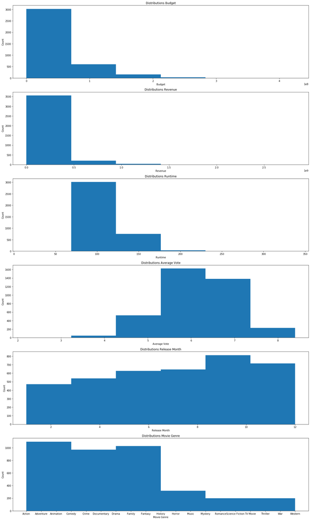

```python
# creating the subplot for the following columns: budget, revenue, runtime, release month, genre

fig, axes = plt.subplots(nrows=6, ncols=1, figsize=(18,30))
ax0, ax1, ax2, ax3, ax4, ax5 = axes.flatten()
n_bins = 6
plt.setp(axes.flat, ylabel='Count')

ax0.hist(df.budget,n_bins)
ax0.set(title = 'Distributions Budget', xlabel='Budget')

ax1.hist(df.revenue,n_bins)
ax1.set(title = 'Distributions Revenue', xlabel='Revenue')

ax2.hist(df.runtime, n_bins)
ax2.set(title = 'Distributions Runtime', xlabel='Runtime')

ax3.hist(df.vote_average, n_bins)
ax3.set(title = 'Distributions Average Vote', xlabel='Average Vote')

ax4.hist(df.release_month, n_bins)
ax4.set(title = 'Distributions Release Month', xlabel='Release Month')

ax5.hist(df.new_genre, n_bins)
ax5.set(title = 'Distributions Movie Genre', xlabel='Movie Genre')

fig.tight_layout();
```

The Histograms show that data for revenue, budget and runtime is right-skewed while the data for the release month and the movie genre have a multimodal distribution.

The date for the rating is normal distributed. (But other distributions can look like a normal distribution. You would need statistical calculations to prove a normal distribution (source: http://asq.org/learn-about-quality/data-collection-analysis-tools/overview/histogram2.html)

The histogram shows a multimodal distribution for the genre

### Scatterplots of revenue against various Features

In order see investigate if there corrletion between various factors and revenue, I will plot them against revenue and I will also calclutate the correlation coefficient to if there is a correlation/linear relation and if the correlation is negative or postive (Source for the analyzis: https://www.dummies.com/education/math/statistics/how-to-interpret-a-correlation-coefficient-r/)

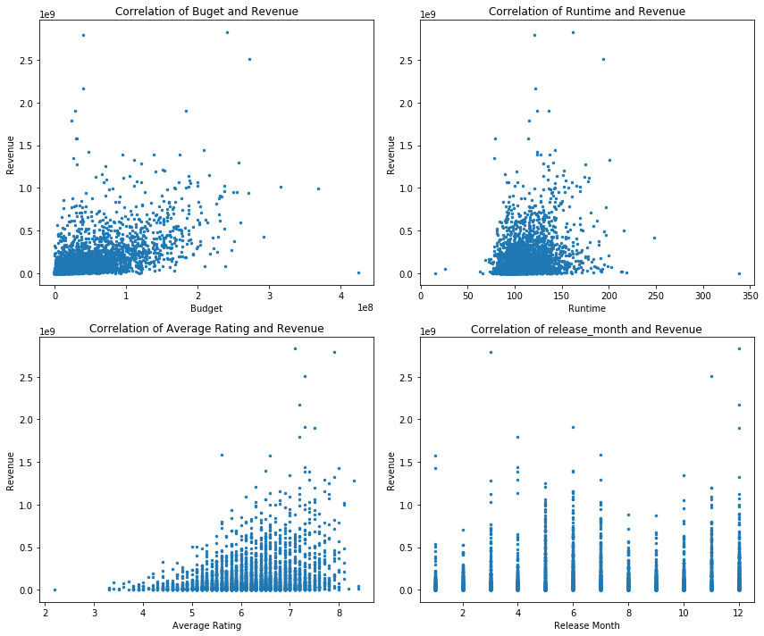

```python
# plotting the following columns/factors against revenue: budget, runtime, release month

fig, axes = plt.subplots(nrows=2, ncols=2, figsize=(12,10))
ax0, ax1, ax2, ax3= axes.flatten()
n_bins = 6
plt.setp(axes.flat, ylabel='Revenue')

ax0.scatter(df.budget, df.revenue, n_bins)
ax0.set(title = 'Correlation of Buget and Revenue', xlabel='Budget')

ax1.scatter(df.runtime, df.revenue, n_bins)
ax1.set(title = 'Correlation of Runtime and Revenue', xlabel='Runtime')

ax2.scatter(df.vote_average, df.revenue, n_bins)
ax2.set(title = 'Correlation of Average Rating and Revenue', xlabel='Average Rating')

ax3.scatter(df.release_month, df.revenue, n_bins)
ax3.set(title = 'Correlation of release_month and Revenue', xlabel='Release Month')


fig.tight_layout();
```

Now I will also calculate the correlation coefficient to support the visuals of the scatterplots

```python
# Correlation Coffiecent budget/revenue
df['budget'].corr(df['revenue'])
```

```
0.56809630383568821
```

```python
# Correlation Coffiecent budget/runtime
df['runtime'].corr(df['revenue'])
```

```
0.27899097786192623
```

```python
# Correlation Coffiecent budget/average rating
df['vote_average'].corr(df['revenue'])
```

```
0.26832037319155422
```

```python
# Correlation Coffiecent budget/release month
df['release_month'].corr(df['revenue'])
```

```
0.054521927555963953
```

#### Now I will interpretate the findings and if needed further investigate the data

##### Correlation of Budget and Revenue

The scatterplot shows moderate uphill positive relation between the budget of a movie and its revenue. This is supported by the correlation cofficient (0.56) for the two factors which also shows a moderate postive correlation.

##### Correlation of Runtime and Revenue

The scatterplot shows no linear relation between the runtime of a movie and its revenue. This is supported by the correlation cofficient (0.27) for the two factors which also shows no linear relation. However, it would be interesting to see which runtime generates the highest average revenue

```python
# max of average revenue grouped by the runtime
df.groupby('runtime').revenue.mean().max()
```

```
2506405735.0
```

```python
# runtime of max value of the average revenue
df.groupby('runtime').revenue.mean().idxmax()
```

```
194.0
```

```python
df[df.runtime == 194]
```

|  | id | imdb_id | popularity | original_title | runtime | vote_average | release_year | budget | revenue | release_month | new_genre | new_production_companies |
| --- | --- | --- | --- | --- | --- | --- | --- | --- | --- | --- | --- | --- |
| 5231 | 597 | tt0120338 | 4.355219 | Titanic | 194.0 | 7.3 | 1997 | 271692064.0 | 2.506406e+09 | 11 | Drama | Paramount Pictures |

Since there is just one movie that has a runtime of 194 ('Titanic'), the result are not really valueable. I will also deivide the runtime into two groups: high runtime; low runtime. Maybe this will give me a better picture how the runtime effects the revenue

```python
df.runtime.describe()
```

```
count    3807.000000
mean      109.367481
std        19.855884
min        15.000000
25%        96.000000
50%       106.000000
75%       119.000000
max       338.000000
Name: runtime, dtype: float64
```

```python
# dividing runtime into two dataframes: high runtime and low runtime
df_runtime_low = df[df.runtime < 102]
df_runtime_high = df[df.runtime >= 102]
```

```python
# average revenue of runtime in dataframe low runtime
low = df_runtime_low.revenue.mean()
low
```

```
93478588.22129032
```

```python
# average revenue of runtime in dataframe low runtime
high = df_runtime_high.revenue.mean()
high
```

```
169664810.98006204
```

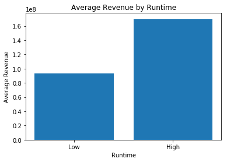

```python
locations = [1, 2]
heights = [low, high]
labels = ['Low', 'High']
plt.bar(locations, heights, tick_label=labels)
plt.title('Average Revenue by Runtime')
plt.xlabel('Runtime')
plt.ylabel('Average Revenue');
```

The results show really clear that movie with a runtime longer then 102 generates in average more revenue

##### Correlation of Rating and Revenue

The scatterplot shows no linear relation between the rating of a movie and its revenue. This is supported by the correlation cofficient (0.26) for the two factors which also shows no linear relation.

##### Correlation of Release Month and Revenue

The scatterplot shows no linear relation between the release month of a movie and its revenue. This is supported by the correlation cofficient (0.05) for the two factors which also shows no linear relation. However, it would be interesttin to see which month generates the most average revenue

```python
# average revenue grouped by month
month_average_mean = df.groupby('release_month').revenue.mean()
month_average_mean
```

```
release_month
1     7.313447e+07
2     8.496709e+07
3     1.334602e+08
4     1.134890e+08
5     2.054063e+08
6     2.317959e+08
7     1.785349e+08
8     8.981934e+07
9     6.415862e+07
10    1.019284e+08
11    1.852493e+08
12    1.918190e+08
Name: revenue, dtype: float64
```

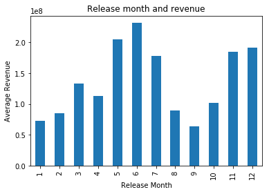

```python
# plotting average revenue grouped by month in a bar chart
month_average_mean.plot(kind="bar")
plt.title("Release month and revenue")
plt.xlabel("Release Month")
plt.ylabel("Average Revenue");
```

The findings shows that the release of the move in June generates the highest revenue and that the release in September generates the lowest revenue.

#### Does the genre effects the revenue? Which genre generates the most revenue?

```python
# average revenue grouped by genre
genre_revenue_mean = df.groupby('new_genre').revenue.mean().round()
genre_revenue_mean.idxmax()
```

```
'Adventure'
```

```python
genre_revenue_mean.idxmin()
```

```
'Documentary'
```

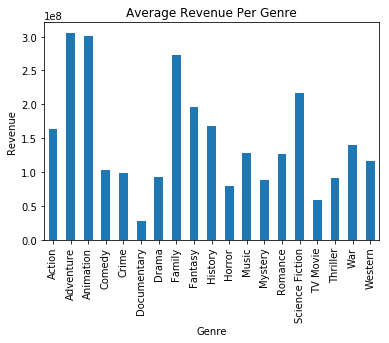

```python
# plotting average revenue grouped by genre in a bar chart
genre_revenue_mean.plot(kind='bar', sort_columns=True)
plt.title('Average Revenue Per Genre')
plt.xlabel('Genre')
plt.ylabel('Revenue');
```

The findings shows that Adventure Movies generate the highest revenue and that Documentary Movies generate the lowest revenue.

#### Which Production Company generates the most revenue?

```python
# counting of productions companies in the dataframe
amount_productions = df.new_production_companies.value_counts()
amount_productions.describe()
```

```
count    893.000000
mean       4.263158
std       17.721790
min        1.000000
25%        1.000000
50%        1.000000
75%        2.000000
max      283.000000
Name: new_production_companies, dtype: float64
```

```python
# average revenue grouped by production companies
max_revenue = df.groupby('new_production_companies').revenue.mean()
max_revenue.idxmax()
```

```
'Robert Wise Productions'
```

```python
df[df.new_production_companies == 'Robert Wise Productions']
```

|  | id | imdb_id | popularity | original_title | runtime | vote_average | release_year | budget | revenue | release_month | new_genre | new_production_companies |
| --- | --- | --- | --- | --- | --- | --- | --- | --- | --- | --- | --- | --- |
| 10690 | 15121 | tt0059742 | 1.313676 | The Sound of Music | 174.0 | 7.2 | 1965 | 56748622.0 | 1.129535e+09 | 3 | Drama | Robert Wise Productions |

The most average revenue was generate by a company that was just one time head production company. This seems more like a lucky punch than a success pattern.

## Scatterplots of rating against various Features

In order see investigate if there corrletion between various factors and the rating of a movie, I will plot them against the rating and I will also calclutate the correlation coefficient to if there is a correlation/linear relation and if the correlation is negative or postive (Source for the analyzis: https://www.dummies.com/education/math/statistics/how-to-interpret-a-correlation-coefficient-r/)

What kind of properties are asccosiated with movies that have high ratings: Does the budget, the release month, the runtime, the genre or the revenue have a positive effect on the rating?

[figure not shown]

```python
# plotting the following columns/factors against revenue: budget, runtime, release month
fig, axes = plt.subplots(nrows=2, ncols=2, figsize=(12,12))
ax0, ax1, ax2, ax3 = axes.flatten()
n_bins = 6
plt.setp(axes.flat, ylabel='Average Rating')

ax0.scatter(df.budget, df.revenue, n_bins)
ax0.set(title = 'Correlation of Buget and Average Rating', xlabel='Budget')

ax1.scatter(df.runtime, df.revenue, n_bins)
ax1.set(title = 'Correlation of Runtime and Average Rating', xlabel='Runtime')

ax2.scatter(df.vote_average, df.revenue, n_bins)
ax2.set(title = 'Correlation of Average Revenue and Average Rating', xlabel='Average Rating')

ax3.scatter(df.release_month, df.revenue, n_bins)
ax3.set(title = 'Correlation of release_month and Average Rating', xlabel='Release Month')

fig.tight_layout();
```

Now I will also calculate the correlation coefficient to support the visuals of the scatterplots

```python
# Correlation Coffiecent budget/Rating
df['budget'].corr(df['vote_average'])
```

```
0.036014926878152012
```

```python
# Correlation Coffiecent release month/Rating
df['release_month'].corr(df['vote_average'])
```

```
0.12517865806181122
```

```python
# Correlation Coffiecent runtime/Rating
df['runtime'].corr(df['vote_average'])
```

```
0.3580074867551688
```

```python
# Correlation Coffiecent revenue/Rating
df['revenue'].corr(df['vote_average'])
```

```
0.26832037319155422
```

#### Now I will interpretate the findings and if needed further investigate the data

##### Correlation of Runtime and Rating

```python
# I will use the two dataframes high runtime and low runtime (which divides runtime into two dataframes:
# high runtime and low runtime and calculate the mean of the rating (vote_average) for each of the two df.
low_runtime_vote = df_runtime_low.vote_average.mean()
low_runtime_vote
```

```
5.8924516129032254
```

```python
high_runtime_vote = df_runtime_high.vote_average.mean()
high_runtime_vote
```

```
6.3612317235268048
```

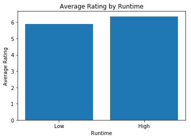

```python
# I will now display the mean of the rating (vote_average) for each of the two dataframes
# in a bar chart (high runtime and low runtime)
locations = [1, 2]
heights = [low_runtime_vote, high_runtime_vote]
labels = ['Low', 'High']
plt.bar(locations, heights, tick_label=labels)
plt.title('Average Rating by Runtime')
plt.xlabel('Runtime')
plt.ylabel('Average Rating');
```

The average rating is slighty higher for longer movies.

```python
df.vote_average.describe()
```

```
count    3807.00000
mean        6.17037
std         0.79232
min         2.20000
25%         5.70000
50%         6.20000
75%         6.70000
max         8.40000
Name: vote_average, dtype: float64
```

#### Summary

In summary, rhe scatterplots and the correlation coefficient shows that just runtime has a weka linear (postiv) relation with ratings of a movie.

#### But does the genre or production_companies effects the raintg? Which genre/ production company generates the best ratings?

```python
# average rating (vote_average) grouped by genre
genre_rating_mean = df.groupby('new_genre').vote_average.mean()
genre_rating_mean.idxmax()
```

```
'Documentary'
```

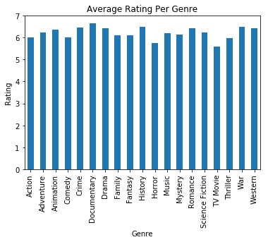

```python
# plotting the average rating (vote_average)grouped by genre in a bar chart
genre_rating_mean.plot(kind='bar', sort_columns=True)
plt.title('Average Rating Per Genre')
plt.xlabel('Genre')
plt.ylabel('Rating');
```

Which Production Company generates the best ratings?

```python
# average rating (vote_average) grouped by production companies
max_rating = df.groupby('new_production_companies').vote_average.mean()
max_rating.idxmax()
```

```
'Talking Heads'
```

```python
df[df.new_production_companies == 'Talking Heads']
```

|  | id | imdb_id | popularity | original_title | runtime | vote_average | release_year | budget | revenue | release_month | new_genre | new_production_companies |
| --- | --- | --- | --- | --- | --- | --- | --- | --- | --- | --- | --- | --- |
| 7948 | 24128 | tt0088178 | 0.283191 | Stop Making Sense | 88.0 | 8.4 | 1984 | 2518850.0 | 10450966.0 | 11 | Documentary | Talking Heads |

The most average rating was generate by a company that was just one time head production company. This seems againmore like a lucky punch than a success pattern.

### Which year has the highest average in ratings? Does the ratings have changed over time: Have movies become better worse?

```python
# average rating (vote_average) grouped by release year
year_average_rating = df.groupby('release_year').vote_average.mean();
```

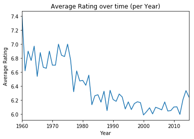

```python
year_average_rating.plot()
plt.title("Average Rating over time (per Year)")
plt.xlabel("Year")
plt.ylabel("Average Rating");
```

```python
year_average_rating.idxmax()
```

```
1960
```

```python
year_average_rating.idxmin()
```

```
2000
```

One can cleary see that the average rating has been going down after the peak in 1960.

## Conclusions

My main goal in this analyzis was to find was to find factors that couls predict the success of a movie in terms of revenue and rating.

The only two correlatons I found was a moderate uphill positive relation/ correlation between the budget of a movie and its revenue and a weak uphill positive relation/ correlation between the runtime and the rating of a movie. Meaning that the higher the budget, the higher the revenue. But its important to note that this a correlation and not a causation. It would be interesting to further investigate this in a regressions model to see if a higher bugdet leads to a higher revenue.

The investigation of the prodcution companies didn't lead to valid findings.

In summary, the only correlation (the only factor that may predict the succes of a movie in terms of revenue and rating) I could find was a moderate postive correlation between the movie and the revenue.

As mentioned before, you need to further investigate the data in order to find causations and to make statistical valid statements. But my analyzis can be taken as first step to understand the relationship between various factors of a movie and its sucess.

## Limitations

As mentioned before, you need to further investigate the data in order to find causations and to make statistical valid statements about the dataset. The findings in this analyzis shows just correlations resp. observation that could be caused by other factors that were not included in the dataframe. The findings have more a desriptive charakter and can't not be used as general statements. Furthermore, the cleaned dateframe just includes 3807 movies and its not really clear if they are picked randomly. Therefore, the dataset can not be used as a representation for all movies. For further investigations one needs to pick a represenative sample of all movies. Due to incomplete values in the dataset, I decided to emlinate all null values, which also limits the value of the findings. Moreover, I decided to just includ the first value of the list of genres and production companies for each movie and I also decided to not includ revenues and bugets that have the value 0 $. This decisions alos limits the explanatory power of my findings.

But my analyzis can be taken as first step to understand the relationship between various factors of a movie and its sucess.